# R Notebook

carla

18/04/21

# Integrantes

- Carla Oñate Gardella A01653555
- Léa Rodríguez Jouault A01659896
- Adahir Cortez Zavala A01660523

```r
setwd("/Users/carla/WebstormProjects/NotasClaseR/Clase 6")
library("Biostrings")
library("seqinr")
```

## Secuencia de la manzana

```r
apple <- read.fasta("./apple_chr_1.fasta")
table(apple$CM007867.1)  # Nos da cuantas A,C,T,G hay en esa lista
```

```
##
##       a       c       g       n       t
## 8380186 5186418 5205188 5580210 8357646
```

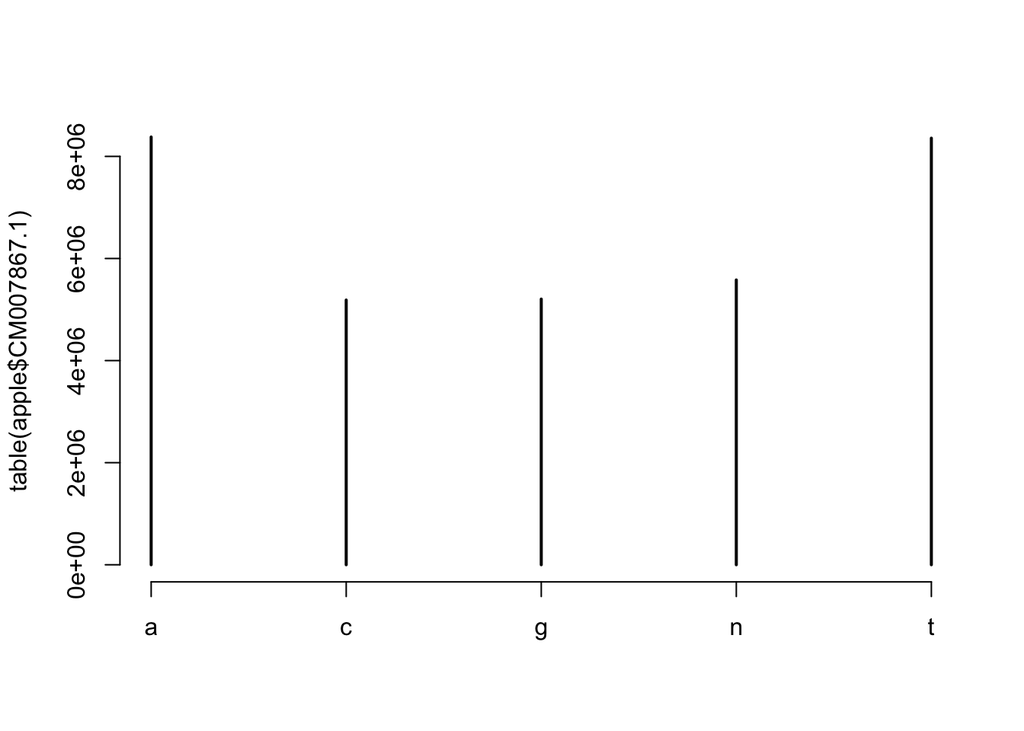

```r
plot(table(apple$CM007867.1)) # Grafica los datos del table (los datos de A,C,T,G en x, cantidad en x)
```

## Secuencia de la banana

```r
banana <- read.fasta("./banana.fasta")
table(banana$NC_025202.1) # Nos da cuantas A,C,T,G hay en esa lista
```

```
##
##       a       c       g       n       t
## 7402595 4655381 4659557 3461827 7394269
```

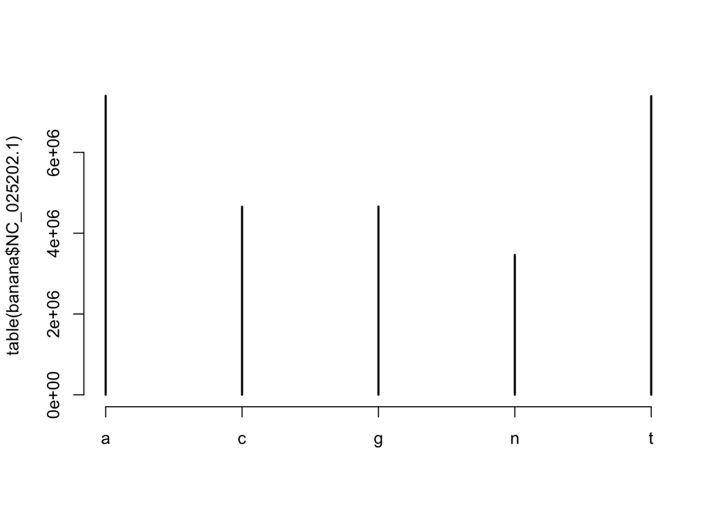

```r
plot(table(banana$NC_025202.1)) # Grafica los datos del table (los datos de A,C,T,G en x, cantidad en x)
```

## Secuencia del Dengue

```r
dengue <- read.fasta("./dengue.fasta")
table(dengue$NC_002640.1) # Nos da cuantas A,C,T,G hay en esa lista
```

```
##
##    a    c    g    t
## 3298 2214 2804 2333
```

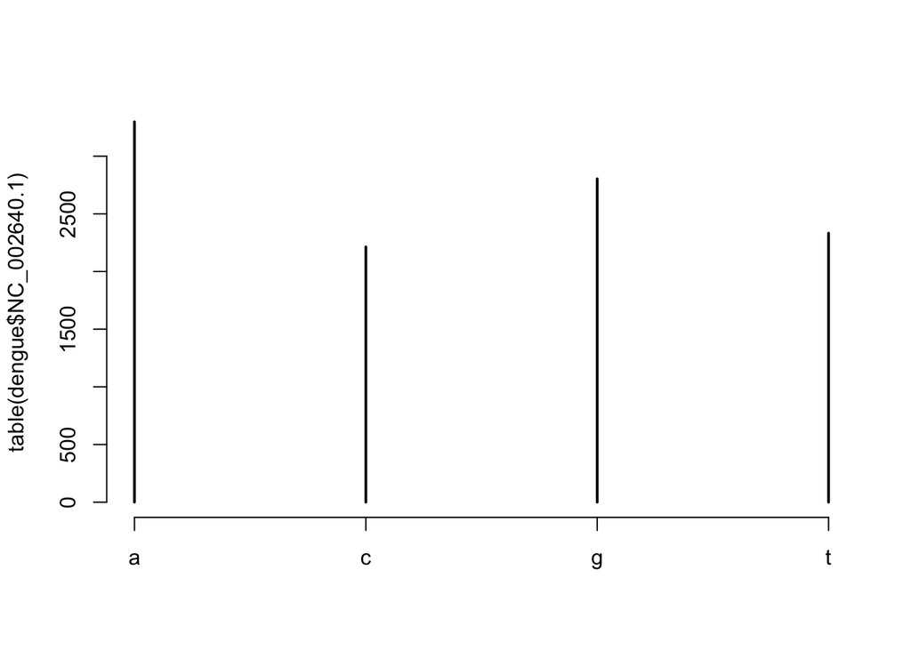

```r
plot(table(dengue$NC_002640.1)) # Grafica los datos del table (los datos de A,C,T,G en x, cantidad en x)
```

## Secuencia del Zika

```r
zika <- read.fasta("./ZIKAseq.fasta")
table(zika$NC_012532.1) # Nos da cuantas A,C,T,G hay en esa lista
```

```
##
##    a    c    g    t
## 2991 2359 3139 2305
```

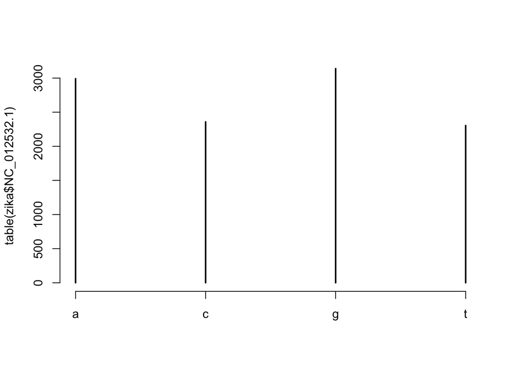

```r
plot(table(zika$NC_012532.1)) # Grafica los datos del table (los datos de A,C,T,G en x, cantidad en x)
```

## Comparaciones

### Comparación Manzana vs Banana

```r
var.test(table(apple$CM007867.1), table(banana$NC_025202.1))
```

```
##
##  F test to compare two variances
##
## data:  table(apple$CM007867.1) and table(banana$NC_025202.1)
## F = 0.87828, num df = 4, denom df = 4, p-value = 0.9029
## alternative hypothesis: true ratio of variances is not equal to 1
## 95 percent confidence interval:
##  0.09144424 8.43545629
## sample estimates:
## ratio of variances
##          0.8782789
```

Podemos observar que el p-value es bastante elevado por lo que podemos concluir que no hay mucha diferencia entre las variancias.

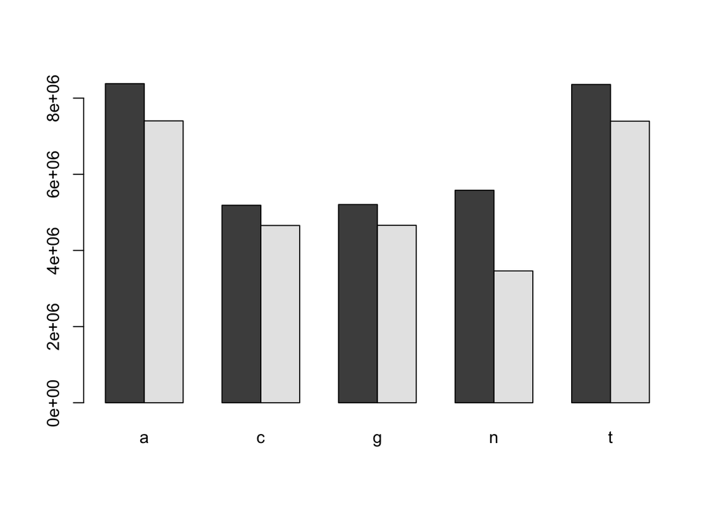

```r
appleVec <- table(apple$CM007867.1)
bananaVec <- table(banana$NC_025202.1)
test <- rbind(appleVec, bananaVec)
barplot(test, beside = TRUE)
```

Podemos ver que hay una gran cantidad de adenina (a) y timina (t) en ambos pero la manzana tiene mucho más que la manzana. Además observamos que la manzana tiene muchos más nucleotidos desconocidos (n). En general el genoma de la manzana es mucho más larga que la de la banana.

## Comparación Dengue vs Zika

```r
var.test(table(dengue$NC_002640.1), table(zika$NC_012532.1))
```

```
##
##  F test to compare two variances
##
## data:  table(dengue$NC_002640.1) and table(zika$NC_012532.1)
## F = 1.3346, num df = 3, denom df = 3, p-value = 0.8182
## alternative hypothesis: true ratio of variances is not equal to 1
## 95 percent confidence interval:
##   0.08643963 20.60447177
## sample estimates:
## ratio of variances
##           1.334557
```

Podemos observar que el p-value es elevado por lo que podemos concluir que no hay mucha diferencia entre las variancias.

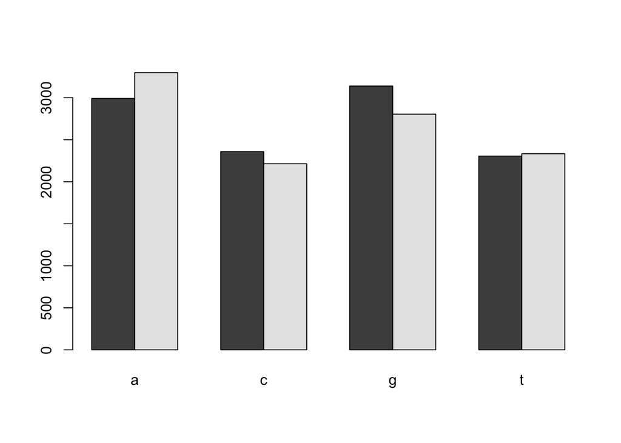

```r
zikaVec <- table(zika$NC_012532.1)
dengueVec <- table(dengue$NC_002640.1)
test <- rbind(zikaVec, dengueVec)
barplot(test, beside = TRUE)
```

Podemos observar que la la cantidad de nucleótidos es más parecida entre los dos virus. Tenemos aproximadamnete la misma cantidad de timina (t) en los dos.

## Comparación Dengue vs Banana

```r
var.test(table(dengue$NC_002640.1), table(banana$NC_025202.1))
```

```
##
##  F test to compare two variances
##
## data:  table(dengue$NC_002640.1) and table(banana$NC_025202.1)
## F = 7.6531e-08, num df = 3, denom df = 4, p-value = 6.876e-11
## alternative hypothesis: true ratio of variances is not equal to 1
## 95 percent confidence interval:
##  7.669081e-09 1.155697e-06
## sample estimates:
## ratio of variances
##       7.653128e-08
```

```r
bananaVec <- table(banana$NC_025202.1)
dengueVec <- table(dengue$NC_002640.1)
test <- rbind(bananaVec, dengueVec)
```

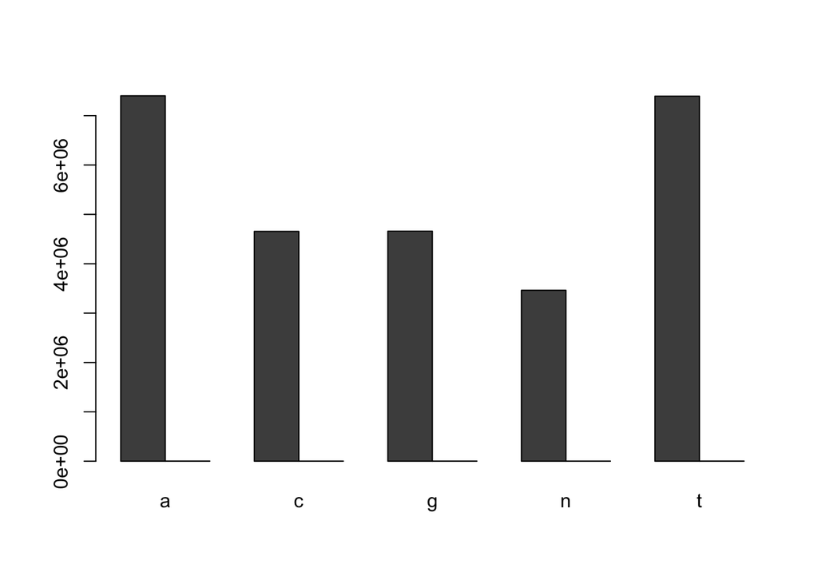

```r
barplot(test, beside = TRUE)
```